# Risk Factor Analysis

## Outcome Variable

**Outcome Variable:** ever_stunted

## Predictor Variables

**Intervention Variable:** hdlvry

**Adjustment Set:**

unadjusted

## Stratifying Variables

The analysis was stratified on these variable(s):

- agecat
- studyid

The following strata were considered:

- agecat: 12 months, studyid: ki1000108-CMC-V-BCS-2002
- agecat: 12 months, studyid: ki1000108-IRC
- agecat: 12 months, studyid: ki1000109-EE
- agecat: 12 months, studyid: ki1000304b-SAS-CompFeed
- agecat: 12 months, studyid: ki1000304b-SAS-FoodSuppl
- agecat: 12 months, studyid: ki1017093c-NIH-Crypto
- agecat: 12 months, studyid: ki1066203-TanzaniaChild2
- agecat: 12 months, studyid: ki1113344-GMS-Nepal
- agecat: 12 months, studyid: ki1135781-COHORTS
- agecat: 12 months, studyid: kiGH5241-JiVitA-3
- agecat: 12 months, studyid: kiGH5241-JiVitA-4
- agecat: 18 months, studyid: ki1000108-CMC-V-BCS-2002
- agecat: 18 months, studyid: ki1000108-IRC
- agecat: 18 months, studyid: ki1000109-EE
- agecat: 18 months, studyid: ki1000304b-SAS-CompFeed
- agecat: 18 months, studyid: ki1000304b-SAS-FoodSuppl
- agecat: 18 months, studyid: ki1017093c-NIH-Crypto
- agecat: 18 months, studyid: ki1066203-TanzaniaChild2
- agecat: 18 months, studyid: ki1113344-GMS-Nepal
- agecat: 18 months, studyid: kiGH5241-JiVitA-3
- agecat: 18 months, studyid: kiGH5241-JiVitA-4
- agecat: 24 months, studyid: ki1000108-CMC-V-BCS-2002
- agecat: 24 months, studyid: ki1000108-IRC
- agecat: 24 months, studyid: ki1000109-EE
- agecat: 24 months, studyid: ki1000304b-SAS-CompFeed
- agecat: 24 months, studyid: ki1000304b-SAS-FoodSuppl
- agecat: 24 months, studyid: ki1017093c-NIH-Crypto
- agecat: 24 months, studyid: ki1066203-TanzaniaChild2
- agecat: 24 months, studyid: ki1113344-GMS-Nepal
- agecat: 24 months, studyid: kiGH5241-JiVitA-4
- agecat: 3 months, studyid: ki1000108-CMC-V-BCS-2002
- agecat: 3 months, studyid: ki1000108-IRC
- agecat: 3 months, studyid: ki1000109-EE
- agecat: 3 months, studyid: ki1000304b-SAS-CompFeed
- agecat: 3 months, studyid: ki1017093c-NIH-Crypto
- agecat: 3 months, studyid: ki1066203-TanzaniaChild2
- agecat: 3 months, studyid: ki1113344-GMS-Nepal
- agecat: 3 months, studyid: ki1135781-COHORTS
- agecat: 3 months, studyid: kiGH5241-JiVitA-3
- agecat: 3 months, studyid: kiGH5241-JiVitA-4
- agecat: 6 months, studyid: ki1000108-CMC-V-BCS-2002
- agecat: 6 months, studyid: ki1000108-IRC
- agecat: 6 months, studyid: ki1000109-EE
- agecat: 6 months, studyid: ki1000304b-SAS-CompFeed
- agecat: 6 months, studyid: ki1000304b-SAS-FoodSuppl
- agecat: 6 months, studyid: ki1017093c-NIH-Crypto
- agecat: 6 months, studyid: ki1066203-TanzaniaChild2
- agecat: 6 months, studyid: ki1113344-GMS-Nepal
- agecat: 6 months, studyid: kiGH5241-JiVitA-3
- agecat: 6 months, studyid: kiGH5241-JiVitA-4

## Methods Detail

# Results Detail

## Results Plots

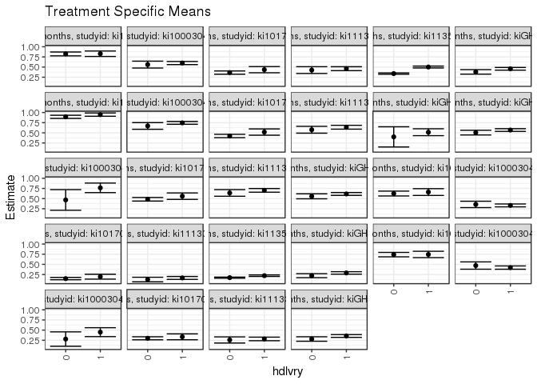

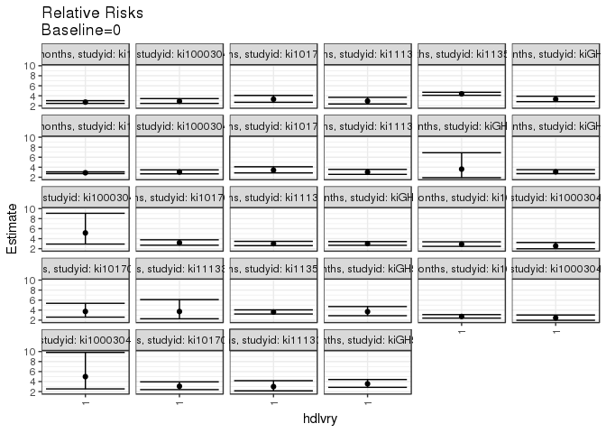

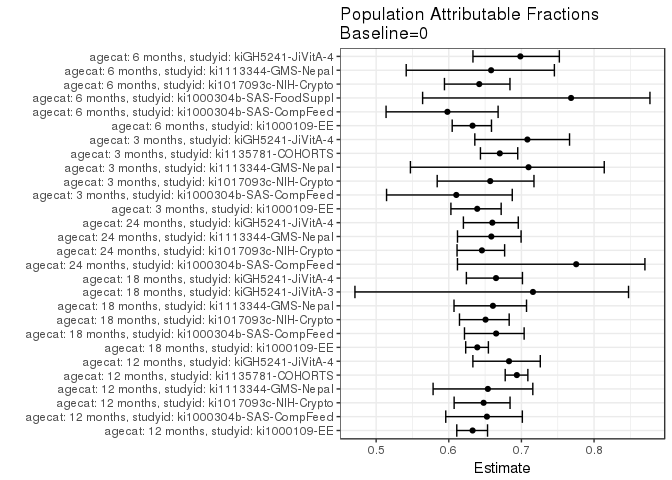

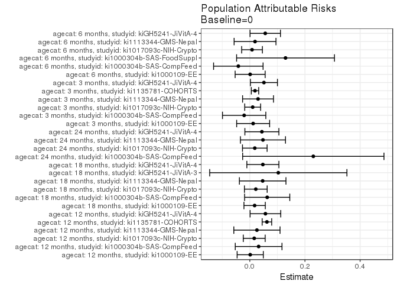

## Data Summary

| agecat | studyid | A | n | nA | nAY0 | nAY1 |
| --- | --- | --- | --- | --- | --- | --- |
| 12 months | ki1000108-CMC-V-BCS-2002 | 0 | 369 | 361 | 109 | 252 |
| 12 months | ki1000108-CMC-V-BCS-2002 | 1 | 369 | 8 | 3 | 5 |
| 12 months | ki1000108-IRC | 0 | 408 | 400 | 199 | 201 |
| 12 months | ki1000108-IRC | 1 | 408 | 8 | 2 | 6 |
| 12 months | ki1000109-EE | 0 | 371 | 249 | 44 | 205 |
| 12 months | ki1000109-EE | 1 | 371 | 122 | 21 | 101 |
| 12 months | ki1000304b-SAS-CompFeed | 0 | 756 | 132 | 58 | 74 |
| 12 months | ki1000304b-SAS-CompFeed | 1 | 756 | 624 | 250 | 374 |
| 12 months | ki1000304b-SAS-FoodSuppl | 0 | 99 | 24 | 3 | 21 |
| 12 months | ki1000304b-SAS-FoodSuppl | 1 | 99 | 75 | 12 | 63 |
| 12 months | ki1017093c-NIH-Crypto | 0 | 729 | 566 | 360 | 206 |
| 12 months | ki1017093c-NIH-Crypto | 1 | 729 | 163 | 92 | 71 |
| 12 months | ki1066203-TanzaniaChild2 | 0 | 469 | 462 | 314 | 148 |
| 12 months | ki1066203-TanzaniaChild2 | 1 | 469 | 7 | 5 | 2 |
| 12 months | ki1113344-GMS-Nepal | 0 | 543 | 134 | 77 | 57 |
| 12 months | ki1113344-GMS-Nepal | 1 | 543 | 409 | 221 | 188 |
| 12 months | ki1135781-COHORTS | 0 | 4747 | 2929 | 1936 | 993 |
| 12 months | ki1135781-COHORTS | 1 | 4747 | 1818 | 907 | 911 |
| 12 months | kiGH5241-JiVitA-3 | 0 | 158 | 17 | 14 | 3 |
| 12 months | kiGH5241-JiVitA-3 | 1 | 158 | 141 | 86 | 55 |
| 12 months | kiGH5241-JiVitA-4 | 0 | 1170 | 294 | 182 | 112 |
| 12 months | kiGH5241-JiVitA-4 | 1 | 1170 | 876 | 476 | 400 |
| 18 months | ki1000108-CMC-V-BCS-2002 | 0 | 370 | 362 | 55 | 307 |
| 18 months | ki1000108-CMC-V-BCS-2002 | 1 | 370 | 8 | 2 | 6 |
| 18 months | ki1000108-IRC | 0 | 409 | 401 | 177 | 224 |
| 18 months | ki1000108-IRC | 1 | 409 | 8 | 2 | 6 |
| 18 months | ki1000109-EE | 0 | 361 | 245 | 26 | 219 |
| 18 months | ki1000109-EE | 1 | 361 | 116 | 6 | 110 |
| 18 months | ki1000304b-SAS-CompFeed | 0 | 736 | 127 | 42 | 85 |
| 18 months | ki1000304b-SAS-CompFeed | 1 | 736 | 609 | 155 | 454 |

[output cut: 80 more lines]

## Results Table

### Parameter: TSM

| agecat | studyid | intervention_level | baseline_level | estimate | ci_lower | ci_upper |
| --- | --- | --- | --- | --- | --- | --- |
| 12 months | ki1000109-EE | 0 | NA | 0.8232932 | 0.7758539 | 0.8707325 |
| 12 months | ki1000109-EE | 1 | NA | 0.8278689 | 0.7607932 | 0.8949445 |
| 12 months | ki1000304b-SAS-CompFeed | 0 | NA | 0.5606061 | 0.4758824 | 0.6453297 |
| 12 months | ki1000304b-SAS-CompFeed | 1 | NA | 0.5993590 | 0.5608852 | 0.6378327 |
| 12 months | ki1017093c-NIH-Crypto | 0 | NA | 0.3639576 | 0.3242927 | 0.4036225 |
| 12 months | ki1017093c-NIH-Crypto | 1 | NA | 0.4355828 | 0.3594121 | 0.5117535 |
| 12 months | ki1113344-GMS-Nepal | 0 | NA | 0.4253731 | 0.3415867 | 0.5091596 |
| 12 months | ki1113344-GMS-Nepal | 1 | NA | 0.4596577 | 0.4113142 | 0.5080012 |
| 12 months | ki1135781-COHORTS | 0 | NA | 0.3390236 | 0.3218784 | 0.3561687 |
| 12 months | ki1135781-COHORTS | 1 | NA | 0.5011001 | 0.4781140 | 0.5240862 |
| 12 months | kiGH5241-JiVitA-4 | 0 | NA | 0.3809524 | 0.3254186 | 0.4364862 |
| 12 months | kiGH5241-JiVitA-4 | 1 | NA | 0.4566210 | 0.4236212 | 0.4896208 |
| 18 months | ki1000109-EE | 0 | NA | 0.8938776 | 0.8552577 | 0.9324974 |
| 18 months | ki1000109-EE | 1 | NA | 0.9482759 | 0.9079173 | 0.9886344 |
| 18 months | ki1000304b-SAS-CompFeed | 0 | NA | 0.6692913 | 0.5874125 | 0.7511702 |
| 18 months | ki1000304b-SAS-CompFeed | 1 | NA | 0.7454844 | 0.7108657 | 0.7801031 |
| 18 months | ki1017093c-NIH-Crypto | 0 | NA | 0.4216216 | 0.3805092 | 0.4627340 |
| 18 months | ki1017093c-NIH-Crypto | 1 | NA | 0.5187500 | 0.4412759 | 0.5962241 |
| 18 months | ki1113344-GMS-Nepal | 0 | NA | 0.5757576 | 0.4913669 | 0.6601482 |
| 18 months | ki1113344-GMS-Nepal | 1 | NA | 0.6377171 | 0.5907450 | 0.6846892 |
| 18 months | kiGH5241-JiVitA-3 | 0 | NA | 0.4000000 | 0.1512458 | 0.6487542 |
| 18 months | kiGH5241-JiVitA-3 | 1 | NA | 0.5149254 | 0.4300202 | 0.5998306 |
| 18 months | kiGH5241-JiVitA-4 | 0 | NA | 0.5052632 | 0.4471918 | 0.5633345 |
| 18 months | kiGH5241-JiVitA-4 | 1 | NA | 0.5684211 | 0.5352071 | 0.6016350 |
| 24 months | ki1000304b-SAS-CompFeed | 0 | NA | 0.4666667 | 0.2122647 | 0.7210687 |
| 24 months | ki1000304b-SAS-CompFeed | 1 | NA | 0.7647059 | 0.6473970 | 0.8820148 |
| 24 months | ki1017093c-NIH-Crypto | 0 | NA | 0.4834711 | 0.4389156 | 0.5280265 |
| 24 months | ki1017093c-NIH-Crypto | 1 | NA | 0.5600000 | 0.4805003 | 0.6394997 |
| 24 months | ki1113344-GMS-Nepal | 0 | NA | 0.6390977 | 0.5573999 | 0.7207956 |
| 24 months | ki1113344-GMS-Nepal | 1 | NA | 0.7027708 | 0.6577705 | 0.7477711 |
| 24 months | kiGH5241-JiVitA-4 | 0 | NA | 0.5560000 | 0.4943797 | 0.6176203 |
| 24 months | kiGH5241-JiVitA-4 | 1 | NA | 0.6143617 | 0.5795554 | 0.6491680 |
| 3 months | ki1000109-EE | 0 | NA | 0.6245059 | 0.5647564 | 0.6842554 |
| 3 months | ki1000109-EE | 1 | NA | 0.6612903 | 0.5778792 | 0.7447014 |
| 3 months | ki1000304b-SAS-CompFeed | 0 | NA | 0.3566434 | 0.2780864 | 0.4352003 |
| 3 months | ki1000304b-SAS-CompFeed | 1 | NA | 0.3318777 | 0.2966448 | 0.3671106 |
| 3 months | ki1017093c-NIH-Crypto | 0 | NA | 0.1491525 | 0.1203885 | 0.1779166 |
| 3 months | ki1017093c-NIH-Crypto | 1 | NA | 0.1964286 | 0.1363119 | 0.2565452 |
| 3 months | ki1113344-GMS-Nepal | 0 | NA | 0.1259259 | 0.0699106 | 0.1819412 |
| 3 months | ki1113344-GMS-Nepal | 1 | NA | 0.1654676 | 0.1297690 | 0.2011663 |
| 3 months | ki1135781-COHORTS | 0 | NA | 0.1723912 | 0.1590002 | 0.1857823 |
| 3 months | ki1135781-COHORTS | 1 | NA | 0.2215223 | 0.2028724 | 0.2401722 |
| 3 months | kiGH5241-JiVitA-4 | 0 | NA | 0.2210145 | 0.1720413 | 0.2699877 |
| 3 months | kiGH5241-JiVitA-4 | 1 | NA | 0.2885057 | 0.2583867 | 0.3186248 |
| 6 months | ki1000109-EE | 0 | NA | 0.7400000 | 0.6855539 | 0.7944461 |
| 6 months | ki1000109-EE | 1 | NA | 0.7438017 | 0.6659159 | 0.8216874 |
| 6 months | ki1000304b-SAS-CompFeed | 0 | NA | 0.4705882 | 0.3808439 | 0.5603325 |
| 6 months | ki1000304b-SAS-CompFeed | 1 | NA | 0.4203152 | 0.3797991 | 0.4608314 |
| 6 months | ki1000304b-SAS-FoodSuppl | 0 | NA | 0.2800000 | 0.1031515 | 0.4568485 |
| 6 months | ki1000304b-SAS-FoodSuppl | 1 | NA | 0.4500000 | 0.3404610 | 0.5595390 |
| 6 months | ki1017093c-NIH-Crypto | 0 | NA | 0.2989510 | 0.2614089 | 0.3364932 |
| 6 months | ki1017093c-NIH-Crypto | 1 | NA | 0.3353659 | 0.2630602 | 0.4076715 |
| 6 months | ki1113344-GMS-Nepal | 0 | NA | 0.2578125 | 0.1819615 | 0.3336635 |
| 6 months | ki1113344-GMS-Nepal | 1 | NA | 0.2828784 | 0.2388634 | 0.3268935 |
| 6 months | kiGH5241-JiVitA-4 | 0 | NA | 0.2812500 | 0.2261468 | 0.3363532 |
| 6 months | kiGH5241-JiVitA-4 | 1 | NA | 0.3561104 | 0.3220721 | 0.3901486 |

### Parameter: E(Y)

| agecat | studyid | intervention_level | baseline_level | estimate | ci_lower | ci_upper |
| --- | --- | --- | --- | --- | --- | --- |
| 12 months | ki1000109-EE | NA | NA | 0.8247978 | 0.8245788 | 0.8250169 |
| 12 months | ki1000304b-SAS-CompFeed | NA | NA | 0.5925926 | 0.5915432 | 0.5936420 |
| 12 months | ki1017093c-NIH-Crypto | NA | NA | 0.3799726 | 0.3778047 | 0.3821404 |
| 12 months | ki1113344-GMS-Nepal | NA | NA | 0.4511971 | 0.4499527 | 0.4524415 |
| 12 months | ki1135781-COHORTS | NA | NA | 0.4010954 | 0.3988539 | 0.4033369 |
| 12 months | kiGH5241-JiVitA-4 | NA | NA | 0.4376068 | 0.4357254 | 0.4394883 |
| 18 months | ki1000109-EE | NA | NA | 0.9113573 | 0.9087332 | 0.9139815 |
| 18 months | ki1000304b-SAS-CompFeed | NA | NA | 0.7323370 | 0.7302556 | 0.7344183 |
| 18 months | ki1017093c-NIH-Crypto | NA | NA | 0.4433566 | 0.4403874 | 0.4463259 |
| 18 months | ki1113344-GMS-Nepal | NA | NA | 0.6224299 | 0.6201644 | 0.6246954 |
| 18 months | kiGH5241-JiVitA-3 | NA | NA | 0.5033557 | 0.4977846 | 0.5089269 |
| 18 months | kiGH5241-JiVitA-4 | NA | NA | 0.5526316 | 0.5510433 | 0.5542198 |
| 24 months | ki1000304b-SAS-CompFeed | NA | NA | 0.6969697 | 0.6666062 | 0.7273332 |
| 24 months | ki1017093c-NIH-Crypto | NA | NA | 0.5015773 | 0.4990436 | 0.5041110 |
| 24 months | ki1113344-GMS-Nepal | NA | NA | 0.6867925 | 0.6844400 | 0.6891449 |
| 24 months | kiGH5241-JiVitA-4 | NA | NA | 0.5998004 | 0.5982359 | 0.6013649 |
| 3 months | ki1000109-EE | NA | NA | 0.6366048 | 0.6348580 | 0.6383516 |
| 3 months | ki1000304b-SAS-CompFeed | NA | NA | 0.3361446 | 0.3355079 | 0.3367812 |
| 3 months | ki1017093c-NIH-Crypto | NA | NA | 0.1596306 | 0.1582318 | 0.1610294 |
| 3 months | ki1113344-GMS-Nepal | NA | NA | 0.1557971 | 0.1543780 | 0.1572162 |
| 3 months | ki1135781-COHORTS | NA | NA | 0.1912535 | 0.1905886 | 0.1919184 |
| 3 months | kiGH5241-JiVitA-4 | NA | NA | 0.2722513 | 0.2705797 | 0.2739229 |
| 6 months | ki1000109-EE | NA | NA | 0.7412399 | 0.7410583 | 0.7414215 |
| 6 months | ki1000304b-SAS-CompFeed | NA | NA | 0.4289855 | 0.4275674 | 0.4304036 |
| 6 months | ki1000304b-SAS-FoodSuppl | NA | NA | 0.4095238 | 0.3956081 | 0.4234395 |
| 6 months | ki1017093c-NIH-Crypto | NA | NA | 0.3070652 | 0.3059697 | 0.3081607 |
| 6 months | ki1113344-GMS-Nepal | NA | NA | 0.2768362 | 0.2759234 | 0.2777489 |
| 6 months | kiGH5241-JiVitA-4 | NA | NA | 0.3372665 | 0.3352687 | 0.3392642 |

### Parameter: RR

[output not shown]

### Parameter: PAR

| agecat | studyid | intervention_level | baseline_level | estimate | ci_lower | ci_upper |
| --- | --- | --- | --- | --- | --- | --- |
| 12 months | ki1000109-EE | 0 | NA | 0.0015047 | -0.0459352 | 0.0489445 |
| 12 months | ki1000304b-SAS-CompFeed | 0 | NA | 0.0319865 | -0.0527436 | 0.1167166 |
| 12 months | ki1017093c-NIH-Crypto | 0 | NA | 0.0160150 | -0.0237091 | 0.0557391 |
| 12 months | ki1113344-GMS-Nepal | 0 | NA | 0.0258239 | -0.0579718 | 0.1096196 |
| 12 months | ki1135781-COHORTS | 0 | NA | 0.0620719 | 0.0447808 | 0.0793630 |
| 12 months | kiGH5241-JiVitA-4 | 0 | NA | 0.0566545 | 0.0010888 | 0.1122201 |
| 18 months | ki1000109-EE | 0 | NA | 0.0174798 | -0.0212291 | 0.0561886 |
| 18 months | ki1000304b-SAS-CompFeed | 0 | NA | 0.0630456 | -0.0188597 | 0.1449509 |
| 18 months | ki1017093c-NIH-Crypto | 0 | NA | 0.0217350 | -0.0194845 | 0.0629545 |
| 18 months | ki1113344-GMS-Nepal | 0 | NA | 0.0466723 | -0.0377487 | 0.1310934 |
| 18 months | kiGH5241-JiVitA-3 | 0 | NA | 0.1033557 | -0.1454608 | 0.3521722 |
| 18 months | kiGH5241-JiVitA-4 | 0 | NA | 0.0473684 | -0.0107247 | 0.1054615 |
| 24 months | ki1000304b-SAS-CompFeed | 0 | NA | 0.2303030 | -0.0259045 | 0.4865106 |
| 24 months | ki1017093c-NIH-Crypto | 0 | NA | 0.0181062 | -0.0265212 | 0.0627336 |
| 24 months | ki1113344-GMS-Nepal | 0 | NA | 0.0476947 | -0.0340370 | 0.1294265 |
| 24 months | kiGH5241-JiVitA-4 | 0 | NA | 0.0438004 | -0.0178398 | 0.1054406 |
| 3 months | ki1000109-EE | 0 | NA | 0.0120988 | -0.0476762 | 0.0718739 |
| 3 months | ki1000304b-SAS-CompFeed | 0 | NA | -0.0204988 | -0.0990583 | 0.0580608 |
| 3 months | ki1017093c-NIH-Crypto | 0 | NA | 0.0104781 | -0.0183200 | 0.0392761 |
| 3 months | ki1113344-GMS-Nepal | 0 | NA | 0.0298712 | -0.0261621 | 0.0859044 |
| 3 months | ki1135781-COHORTS | 0 | NA | 0.0188623 | 0.0054548 | 0.0322698 |
| 3 months | kiGH5241-JiVitA-4 | 0 | NA | 0.0512368 | 0.0022351 | 0.1002385 |
| 6 months | ki1000109-EE | 0 | NA | 0.0012399 | -0.0532065 | 0.0556863 |
| 6 months | ki1000304b-SAS-CompFeed | 0 | NA | -0.0416027 | -0.1313582 | 0.0481528 |
| 6 months | ki1000304b-SAS-FoodSuppl | 0 | NA | 0.1295238 | -0.0478713 | 0.3069189 |
| 6 months | ki1017093c-NIH-Crypto | 0 | NA | 0.0081142 | -0.0294440 | 0.0456723 |
| 6 months | ki1113344-GMS-Nepal | 0 | NA | 0.0190237 | -0.0568328 | 0.0948801 |
| 6 months | kiGH5241-JiVitA-4 | 0 | NA | 0.0560165 | 0.0008771 | 0.1111559 |

### Parameter: PAF

[output not shown]